# PSYCH 260

2020-10-21 14:26:49

## Prelude

[video not shown]

https://www.youtube.com/embed/lioWzrpCtGQ

## Today’s Topics

- The neuroscience of psychiatric disorders
- Major affective (mood) disorders
  - Major Depressive Disorder (depression)
  - Bipolar Disorder

## Mental illness lifetime prevalence

[figure not shown]

## Neuroscience of psychiatric disorders

- Diseases of the mind as disorders of the brain
  - System-wide effects; no single or simple cause
- Heritability
  - *proportion of variance in trait accounted for by genetic factors*
- Higher for psychiatric disorders than non-psychiatric diseases
  - Family member with mental illness highest known risk factor

## Depression

## Major Depressive Disorder

- Symptoms
  - Unhappy mood, insomnia, lethargy, loss of pleasure, interest, energy
- Agitation
- Lasting for several weeks or more

## Depression

- Experienced by ~7% Americans in any year
- Prevalence (up to ~20% lifetime)
  - Females 2-3x males, higher 40+ years of age
- Heritability (large, 2.5 M Swedish population study)
  - Females 0.49 (twins); 0.51 (non-twin relatives)
  - Males 0.41 (twins); 0.36 (non-twin relatives)
  - [(Kendler, Ohlsson, Lichtenstein, Sundquist, & Sundquist, 2018)](http://doi.org/10.1176/appi.ajp.2018.17111251)

## Symptoms, [(Mahar, Bambico, Mechawar, & Nobrega, 2014)](http://doi.org/10.1016/j.neubiorev.2013.11.009)

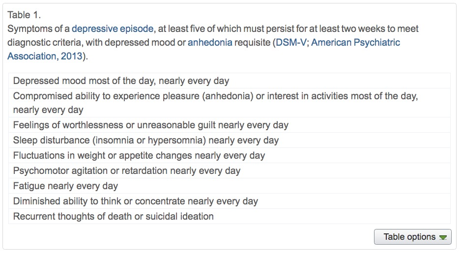

## Neurobiology of Major Depressive Disorder (MDD)

- Reduced sizes of brain regions
- Hypoactivity
- Pharmacological factors
- Synaptic dysfunction

## Neurological factors

- Reduced hippocampal volumes
- [(Videbech & Ravnkilde, 2004a)](http://ajp.psychiatryonline.org/doi/abs/10.1176/appi.ajp.161.11.1957) meta-analysis

## [(Videbech & Ravnkilde, 2004a)](http://ajp.psychiatryonline.org/doi/abs/10.1176/appi.ajp.161.11.1957)

Left Hippocampus

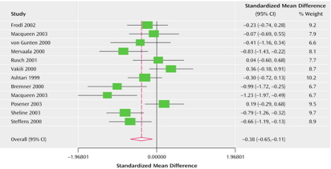

## [(Videbech & Ravnkilde, 2004b)](http://dx.doi.org/10.1176/appi.ajp.161.11.1957)

Right Hippocampus

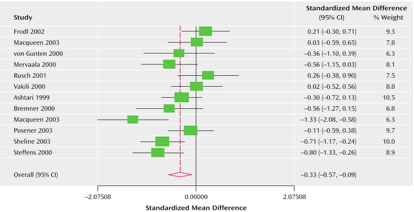

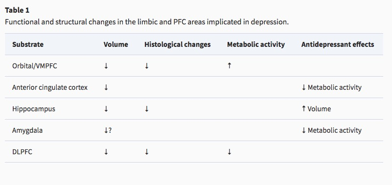

[(Palazidou, 2012)](http://dx.doi.org/10.1093/bmb/lds004)

## Neurological factors

- Hypoactivity in
  - Frontal and temporal cortex
  - Anterior cingulate
  - Insula
  - Cerebellum
- [(Fitzgerald, Laird, Maller, & Daskalakis, 2008)](http://dx.doi.org/10.1002/hbm.20426)

## [(Fitzgerald et al., 2008)](http://dx.doi.org/10.1002/hbm.20426)

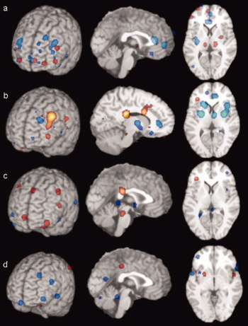

1. patients v. controls, (b) patients on SSRIs, (c) patients v. ctrls (happy stim), (d) patients v. controls (sad stim)

## Baseline hyperactivity [(Hamilton et al., 2012)](https://doi.org/10.1176/appi.ajp.2012.11071105)

[figure not shown]

## Valence-specific hyperactivity [(Hamilton et al., 2012)](https://doi.org/10.1176/appi.ajp.2012.11071105)

[figure not shown]

## Disrupted connectivity

- Resting state fMRI (rsFMRI) in \(n=421\) patients with major depressive disorder and \(n=488\) control subjects.
- *Reduced* connectivity between orbitofrontal cortex (OFC) and other areas of the brain
- *Increased* connectivity between lateral PFC and other brain areas

[(Cheng et al., 2016)](http://doi.org/10.1093/brain/aww255)

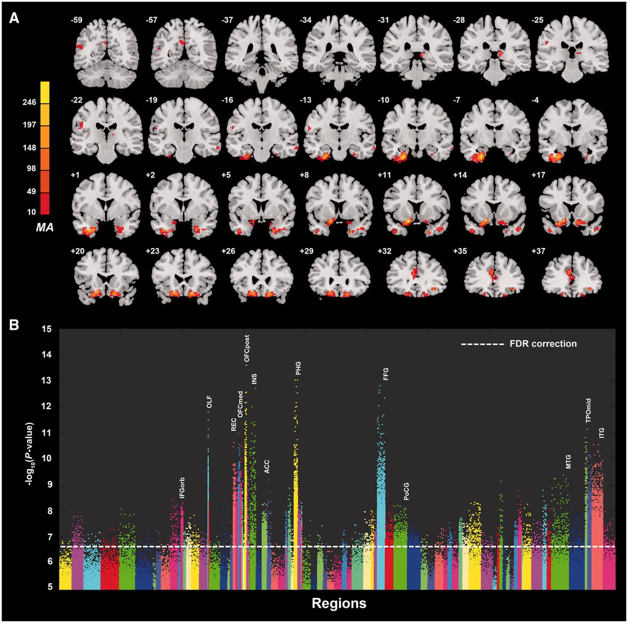

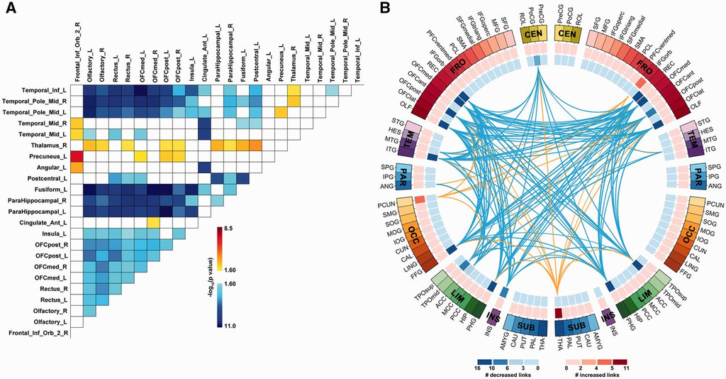

[figure not shown]

[(Palazidou, 2012)](http://dx.doi.org/10.1093/bmb/lds004)

## Pharmacological factors

- Endocrine
  - Thyroid dysfunction [(Medici et al., 2014)](http://dx.doi.org/10.1210/jc.2013-3589)
  - Altered cortisol reactivity [(Burke, Davis, Otte, & Mohr, 2005)](http://dx.doi.org/10.1016/j.psyneuen.2005.02.010)

## Pharmacological factors

- Monoamine hypothesis
  - More: euphoria
  - Less: depression
  - Resperine (antagonist for NE & 5-HT) can cause depression
  - Low serotonin (5-HT) metabolite levels in CSF of suicidal depressives [(Samuelsson, Jokinen, Nordström, & Nordström, 2006)](http://dx.doi.org/10.1111/j.1600-0447.2005.00639.x)

## Measuring 5-HT

- CSF, platelets, plasma, urine, saliva
- CSF & platelets correlate highly [(Audhya, Adams, & Johansen, 2012)](http://dx.doi.org/10.1016/j.bbagen.2012.05.012)
- Salivary 5-HT does not correlate with mood symptoms [(Leung et al., 2018)](http://dx.doi.org/10.1016/j.ymgmr.2018.03.008)

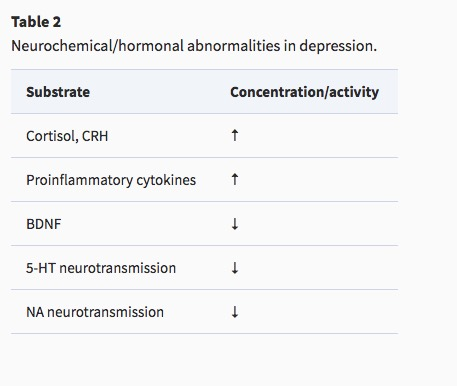

[(Palazidou, 2012)](http://dx.doi.org/10.1093/bmb/lds004)

## Treatments for depression

- Psychotherapy
  - Often effective when combined with drug treatment
- Exercise
- Drugs

## Drugs

- Monoamine oxidase (MAO) inhibitors
  - MAO destroys excess monoamines in terminal buttons
  - MAO-I’s boost monoamine levels
- Tricyclics
  - Inhibit NE, 5-HT reuptake
  - Upregulate monoamine levels, but non-selective = side effects

## Drugs

- Selective Serotonin Reuptake Inhibitors (SSRIs)
  - Fluoxetine (Prozac, Paxil, Zoloft)
  - Prolong duration of 5-HT in synaptic cleft
  - Also increase brain steroid production
- Selective Serotonin Norepinephrine Reuptake Inhibitors (SNRIs)

## Cymbalta (SNRI)

[video not shown]

## How well do the drugs work?

- [STAR*D trial](http://www.nimh.nih.gov/funding/clinical-research/practical/stard/allmedicationlevels.shtml)
- On SSRI for 12-14 weeks. ~1/3 achieved remission; 10-15% showed symptom reduction.
- If SSRI didn’t work, could switch drugs. ~25% became symptom free.
- 16% of participants dropped out due to tolerability issues
- Took 6-7 weeks to show response.

## Who will benefit from drug therapy?

- Depends on
  - Early life stress
  - Brain (amygdala) response to emotional faces
- [(Goldstein-Piekarski et al., 2016)](http://doi.org/10.1073/pnas.1606671113)
- Low-stress + low amyg reactivity -> > responding
- High stress + high amyg reactivity -> > responding

[figure not shown]

[(Goldstein-Piekarski et al., 2016)](http://doi.org/10.1073/pnas.1606671113)

## Monoamine hypothesis of depression

- Disrupted (lowered) levels of monoamines (especially NE & 5-HT) result in depression

## Problems with monoamine hypothesis

- Too simplistic
- NE, 5-HT interact
- Drugs fast acting (min), but improvement slow (weeks)

> “*No correlation between serotonin and its metabolite 5-HIAA in the cerebrospinal fluid and [11C]AZ10419369 binding measured with PET in healthy volunteers.*” [(Tiger et al., 2015)](http://hdl.handle.net/10616/44513)

> “*…we performed the first meta-analysis of the mood effects in [acute tryptophan depletion] ATD and [alpha-methyl-para-tyrosine] APTD studies. The depletion of monoamine systems (both 5-HT and NE/DA) does not decrease mood in healthy controls. However, in healthy controls with a family history of MDD the results suggest that mood is slightly decreased…by [monoamine depletion]…*”

[(Ruhé, Mason, & Schene, 2007)](http://dx.doi.org/10.1038/sj.mp.4001949)

## What do drugs do, then?

- Alter receptor sensitivity?
  - Serotonin presynaptic autoreceptors compensate
  - Postsynaptic upregulation of NE/5-HT effects

## What do drugs do, then?

- Stimulate neurogenesis?
  - Link to neurotrophin, brain-derived nerve growth factor (BDNF)
  - BDNF boosts neurogenesis
  - SSRIs stimulate growth of new neurons in hippocampus

## Neurogenesis hypothesis, [(Mahar et al., 2014)](http://doi.org/10.1016/j.neubiorev.2013.11.009)

- Chronic stress causes neural loss in hipp
- Chronic stress downregulates 5-HT sensitivity
- Depression ~ chronic stress
- Anti-depressants upregulate neurogenesis via 5-HT modulation

[figure not shown]

[Washington Post, 2019-03-06](https://www.washingtonpost.com/health/2019/03/06/biggest-advance-depression-years-fda-approves-novel-treatment-hardest-cases/)

## Ketamine

- Selective antagonist of the NMDA receptor, an ionotropic glutamate receptor
- Relieves depressive symptoms relatively quickly [(Berman et al., 2000)](https://www.ncbi.nlm.nih.gov/pubmed/10686270) and [(Zarate et al., 2006)](http://dx.doi.org/10.1001/archpsyc.63.8.856)
- Boosts synaptic spine formation [(Li et al., 2010)](http://dx.doi.org/10.1126/science.1190287) and reverses effects of induced stress

## Electroconvulsive Therapy (ECT)

- Last line of treatment for drug-resistant depression
- Electric current delivered to the brain causes 30-60s seizure.
- ECT usually done in a hospital’s operating or recovery room under general anesthesia.
- Once every 2 - 5 days for a total of 6 - 12 sessions.

## Electroconvulsive Therapy (ECT)

- Remission rates of up to 50.9% [(Dierckx, Heijnen, Broek, & Birkenhäger, 2012)](http://doi.org/10.1111/j.1399-5618.2012.00997.x)
- Seems to work via
  - Anticonvulsant (block Na+ channel or enhance GABA function) effects
  - Neurotrophic (stimulates neurogenesis) effects

## Patients speak

- Kitty Dukakis’ (wife of former Governor/Presidential candidate Michael Dukakis) story: http://www.nytimes.com/2016/12/31/us/kitty-dukakis-electroshock-therapy-evangelist.html

## Depression’s widespread impact

- Widespread brain dysfunction
- Prefrontal cortex, amygdala, HPA axis, circadian rhythms
- Genetic + environmental factors
- Disturbance in 5-HT, NE systems, cortisol
- Many sufferers do not respond to available treatments

## Points on depression

- Drug treatments affect neuromodulator NT systems, but
  - Can’t effectively measure NT levels
  - Neuromodulators interact, so many side-effects
- ‘Monoamine hypothesis’ of depression is at-best incomplete
- ‘Talk’ therapies can change behavior/mood by creating new/strengthened circuits

## Bipolar disorder

## Bipolar disorder

- Formerly “manic depression” or “manic depressive disorder”
- Alternating mood states
  - Mania or hypomania (milder form)
  - Depression
- Cycles 3-6 mos in length, but
  - Rapid cycling (weeks or days)
- Suicide risk 20-60x normal population, [(Baldessarini, Pompili, & Tondo, 2006)](http://dx.doi.org/10.1017/S1092852900014681)

## Symptoms

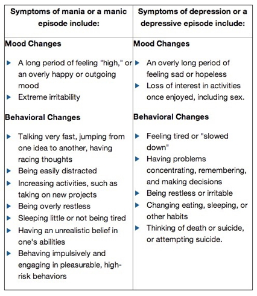

http://www.nimh.nih.gov/health/topics/bipolar-disorder/index.shtml

## Prevalence, subtypes

- 1-3% prevalence, subthreshold affects another 2%
- Subtypes
  - **Bipolar I**: manic episodes, possible depressive ones
  - **Bipolar II**: no manic episodes but hypomania (disinhibition, irritability/agitation) + depression

## Related symptoms

- Psychosis (hallucinations or delusions)
- Anxiety, attention-deficit hyperactivity disorder (ADHD)
- Substance abuse

## Genetics

- Overlap between bipolar disorder and schizophrenia
- Genes for voltage-gated Ca++ channels
  - Regulate NT, hormone release
  - Gene expression, cell metabolism
- (Craddock & Sklar, 2013)

## Brain responses to emotional faces ≠ depression

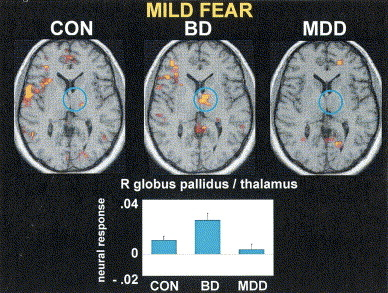

[(Lawrence et al., 2004)](http://dx.doi.org/10.1016/j.biopsych.2003.11.017)

## [(Lawrence et al., 2004)](http://dx.doi.org/10.1016/j.biopsych.2003.11.017)

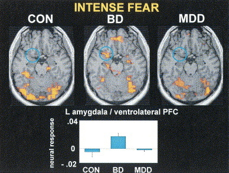

## [(Lawrence et al., 2004)](http://dx.doi.org/10.1016/j.biopsych.2003.11.017)

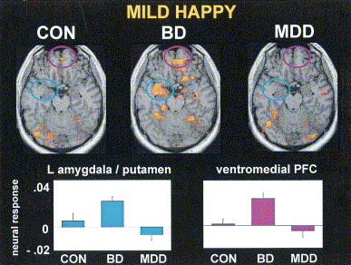

## Amyg, Hip volume reduced; ventricles larger

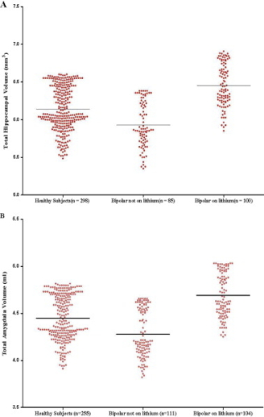

[(Hallahan et al., 2011)](http://dx.doi.org/10.1016/j.biopsych.2010.08.029)

## [(Hallahan et al., 2011)](http://dx.doi.org/10.1016/j.biopsych.2010.08.029)

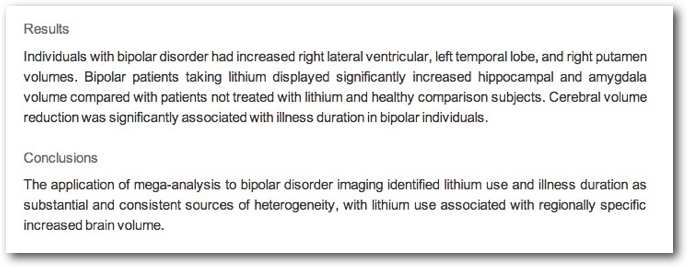

## Drug treatments

- Mood stabilizers
  - Lithium (Li)
  - Valproate (Depakote)
- Anticonvulsants
  - GABA agonists
  - Usually to treat epilepsy
  - e.g. lamotrigine (Lamictal)
- Atypical antipsychotics

## Lithium “discovered” accidentally

- Injections of manic patients’ urine with lithium compound (chemical stabilizer) into guinea pig test animals
- Had calming effect
- [John Cade](https://en.wikipedia.org/wiki/John_Cade) discovered in 1948
- Earliest effective medications for treating mental illness

## Effects of Lithium

- Reduces mania, minimal effects on depressive states
- Preserves PFC, hip, amyg volume
- downregulates DA, glu; upregulates GABA
- modulates 5-HT, NE
- *levels can be tested/monitored via blood test*
- [(Malhi, Tanious, Das, Coulston, & Berk, 2013)](http://dx.doi.org/10.1007/s40263-013-0039-0)

## Other treatment options

- Psychotherapy
- Electroconvulsive Therapy (ECT)
- Sleep medications

## Prospects

- STEP-BD cohort (n=1469)
  - 58% achieved recovery
  - 49% had recurrences within 2 years
  - Residual depressive symptoms can persist
- (Geddes & Miklowitz, 2013)

## An Unquiet Mind

[figure not shown]

## BP summed-up

- Changes in mood, but ≠ depression
- Genetic + environmental risk
- Changes in emotion processing network activity, size of hippocampus
- Heterogeneous
- No simple link to a specific NT system

## Next time…

- Schizophrenia

## References

Audhya, T., Adams, J. B., & Johansen, L. (2012). Correlation of serotonin levels in CSF, platelets, plasma, and urine. *Biochimica et Biophysica Acta*, *1820*(10), 1496–1501. https://doi.org/10.1016/j.bbagen.2012.05.012

Baldessarini, R. J., Pompili, M., & Tondo, L. (2006). Suicide in Bipolar Disorder: Risks and Management. *CNS Spectrums*, *11*(06), 465–471. https://doi.org/10.1017/S1092852900014681

Berman, R. M., Cappiello, A., Anand, A., Oren, D. A., Heninger, G. R., Charney, D. S., & Krystal, J. H. (2000). Antidepressant effects of ketamine in depressed patients. *Biol. Psychiatry*, *47*(4), 351–354. Retrieved from https://www.ncbi.nlm.nih.gov/pubmed/10686270

Burke, H. M., Davis, M. C., Otte, C., & Mohr, D. C. (2005). Depression and cortisol responses to psychological stress: A meta-analysis. *Psychoneuroendocrinology*, *30*(9), 846–856. https://doi.org/10.1016/j.psyneuen.2005.02.010

Cheng, W., Rolls, E. T., Qiu, J., Liu, W., Tang, Y., Huang, C.-C., … Feng, J. (2016). Medial reward and lateral non-reward orbitofrontal cortex circuits change in opposite directions in depression. *Brain*, aww255. https://doi.org/10.1093/brain/aww255

Craddock, N., & Sklar, P. (2013). Genetics of bipolar disorder. *The Lancet*, *381*(9878), 1654–1662. https://doi.org/10.1016/S0140-6736(13)60855-7

Dierckx, B., Heijnen, W. T., Broek, W. W. van den, & Birkenhäger, T. K. (2012). Efficacy of electroconvulsive therapy in bipolar versus unipolar major depression: A meta-analysis. *Bipolar Disorders*, *14*(2), 146–150. https://doi.org/10.1111/j.1399-5618.2012.00997.x

Fitzgerald, P. B., Laird, A. R., Maller, J., & Daskalakis, Z. J. (2008). A meta-analytic study of changes in brain activation in depression. *Human Brain Mapping*, *29*(6), 683–695. https://doi.org/10.1002/hbm.20426

Geddes, J. R., & Miklowitz, D. J. (2013). Treatment of bipolar disorder. *The Lancet*, *381*(9878), 1672–1682. https://doi.org/10.1016/S0140-6736(13)60857-0

Goldstein-Piekarski, A. N., Korgaonkar, M. S., Green, E., Suppes, T., Schatzberg, A. F., Hastie, T., … Williams, L. M. (2016). Human amygdala engagement moderated by early life stress exposure is a biobehavioral target for predicting recovery on antidepressants. *Proceedings of the National Academy of Sciences*, *113*(42), 11955–11960. https://doi.org/10.1073/pnas.1606671113

Hallahan, B., Newell, J., Soares, J. C., Brambilla, P., Strakowski, S. M., Fleck, D. E., … McDonald, C. (2011). Structural Magnetic Resonance Imaging in Bipolar Disorder: An International Collaborative Mega-Analysis of Individual Adult Patient Data. *Biological Psychiatry*, *69*(4), 326–335. https://doi.org/10.1016/j.biopsych.2010.08.029

Hamilton, J. P., Etkin, A., Furman, D. J., Lemus, M. G., Johnson, R. F., & Gotlib, I. H. (2012). Functional neuroimaging of major depressive disorder: A Meta-Analysis and new integration of baseline activation and neural response data. *AJP*, *169*(7), 693–703. https://doi.org/10.1176/appi.ajp.2012.11071105

Kendler, K. S., Ohlsson, H., Lichtenstein, P., Sundquist, J., & Sundquist, K. (2018). The genetic epidemiology of treated major depression in sweden. *The American Journal of Psychiatry*, *175*(11), 1137–1144. https://doi.org/10.1176/appi.ajp.2018.17111251

Lawrence, N. S., Williams, A. M., Surguladze, S., Giampietro, V., Brammer, M. J., Andrew, C., … Phillips, M. L. (2004). Subcortical and ventral prefrontal cortical neural responses to facial expressions distinguish patients with bipolar disorder and major depression. *Biological Psychiatry*, *55*(6), 578–587. https://doi.org/10.1016/j.biopsych.2003.11.017

Leung, J., Selvage, C., Bosdet, T., Branov, J., Rosen-Heath, A., Bishop, C., … Horvath, G. (2018). Salivary serotonin does not correlate with central serotonin turnover in adult phenylketonuria (PKU) patients. *Molecular Genetics and Metabolism Reports*, *15*, 100–105. https://doi.org/10.1016/j.ymgmr.2018.03.008

Li, N., Lee, B., Liu, R.-J., Banasr, M., Dwyer, J. M., Iwata, M., … Duman, R. S. (2010). mTOR-dependent synapse formation underlies the rapid antidepressant effects of NMDA antagonists. *Science*, *329*(5994), 959–964. https://doi.org/10.1126/science.1190287

Mahar, I., Bambico, F. R., Mechawar, N., & Nobrega, J. N. (2014). Stress, serotonin, and hippocampal neurogenesis in relation to depression and antidepressant effects. *Neuroscience & Biobehavioral Reviews*, *38*, 173–192. https://doi.org/10.1016/j.neubiorev.2013.11.009

Malhi, G. S., Tanious, M., Das, P., Coulston, C. M., & Berk, M. (2013). Potential Mechanisms of Action of Lithium in Bipolar Disorder. *CNS Drugs*, *27*(2), 135–153. https://doi.org/10.1007/s40263-013-0039-0

Medici, M., Direk, N., Visser, W. E., Korevaar, T. I. M., Hofman, A., Visser, T. J., … Peeters, R. P. (2014). Thyroid function within the normal range and the risk of depression: A population-based cohort study. *J. Clin. Endocrinol. Metab.*, *99*(4), 1213–1219. https://doi.org/10.1210/jc.2013-3589

Palazidou, E. (2012). The neurobiology of depression. *British Medical Bulletin*, *101*, 127–145. https://doi.org/10.1093/bmb/lds004

Ruhé, H. G., Mason, N. S., & Schene, A. H. (2007). Mood is indirectly related to serotonin, norepinephrine and dopamine levels in humans: A meta-analysis of monoamine depletion studies. *Molecular Psychiatry*, *12*(4), 331–359. https://doi.org/10.1038/sj.mp.4001949

Samuelsson, M., Jokinen, J., Nordström, A.-L., & Nordström, P. (2006). CSF 5-HIAA, suicide intent and hopelessness in the prediction of early suicide in male high-risk suicide attempters. *Acta Psychiatrica Scandinavica*, *113*(1), 44–47. https://doi.org/10.1111/j.1600-0447.2005.00639.x

Tiger, M., Svenningsson, P., Nord, M., Jabre, S., Halldin, C., & Lundberg, J. (2015). No correlation between serotonin and its metabolite 5-HIAA in the cerebrospinal fluid and [11C]AZ10419369 binding measured with PET in healthy volunteers. Retrieved from http://hdl.handle.net/10616/44513

Videbech, P., & Ravnkilde, B. (2004a). Hippocampal volume and depression: A meta-analysis of MRI studies. *Am. J. Psychiatry*, *161*(11), 1957–1966. https://doi.org/10.1176/appi.ajp.161.11.1957

Videbech, P., & Ravnkilde, B. (2004b). Hippocampal volume and depression: A meta-analysis of mri studies. *American Journal of Psychiatry*, *161*(11), 1957–1966. https://doi.org/10.1176/appi.ajp.161.11.1957

Zarate, C. A., Jr, Singh, J. B., Carlson, P. J., Brutsche, N. E., Ameli, R., Luckenbaugh, D. A., … Manji, H. K. (2006). A randomized trial of an N-methyl-D-aspartate antagonist in treatment-resistant major depression. *Arch. Gen. Psychiatry*, *63*(8), 856–864. https://doi.org/10.1001/archpsyc.63.8.856